# Risk Factor Analysis

## Outcome Variable

**Outcome Variable:** wasted

## Predictor Variables

**Intervention Variable:** impfloor

**Adjustment Set:**

- arm
- sex
- W_mage
- meducyrs
- feducyrs
- hhwealth_quart
- hfoodsec
- W_mhtcm
- W_nrooms
- W_nchldlt5
- W_parity
- impsan
- safeh20
- delta_W_mage
- delta_meducyrs
- delta_feducyrs
- delta_hhwealth_quart
- delta_hfoodsec
- delta_W_mhtcm
- delta_W_nrooms
- delta_W_nchldlt5
- delta_W_parity
- delta_impsan
- delta_safeh20

## Stratifying Variables

The analysis was stratified on these variable(s):

- agecat
- studyid
- country

## Data Summary

| agecat | studyid | country | impfloor | wasted | n_cell | n |
| --- | --- | --- | --- | --- | --- | --- |
| Birth | ki0047075b-MAL-ED | BANGLADESH | 1 | 0 | 167 | 222 |
| Birth | ki0047075b-MAL-ED | BANGLADESH | 1 | 1 | 38 | 222 |
| Birth | ki0047075b-MAL-ED | BANGLADESH | 0 | 0 | 17 | 222 |
| Birth | ki0047075b-MAL-ED | BANGLADESH | 0 | 1 | 0 | 222 |
| Birth | ki0047075b-MAL-ED | BRAZIL | 1 | 0 | 159 | 167 |
| Birth | ki0047075b-MAL-ED | BRAZIL | 1 | 1 | 6 | 167 |
| Birth | ki0047075b-MAL-ED | BRAZIL | 0 | 0 | 2 | 167 |
| Birth | ki0047075b-MAL-ED | BRAZIL | 0 | 1 | 0 | 167 |
| Birth | ki0047075b-MAL-ED | INDIA | 1 | 0 | 150 | 188 |
| Birth | ki0047075b-MAL-ED | INDIA | 1 | 1 | 28 | 188 |
| Birth | ki0047075b-MAL-ED | INDIA | 0 | 0 | 8 | 188 |
| Birth | ki0047075b-MAL-ED | INDIA | 0 | 1 | 2 | 188 |
| Birth | ki0047075b-MAL-ED | NEPAL | 1 | 0 | 52 | 159 |
| Birth | ki0047075b-MAL-ED | NEPAL | 1 | 1 | 12 | 159 |
| Birth | ki0047075b-MAL-ED | NEPAL | 0 | 0 | 87 | 159 |
| Birth | ki0047075b-MAL-ED | NEPAL | 0 | 1 | 8 | 159 |
| Birth | ki0047075b-MAL-ED | PERU | 1 | 0 | 53 | 252 |
| Birth | ki0047075b-MAL-ED | PERU | 1 | 1 | 1 | 252 |
| Birth | ki0047075b-MAL-ED | PERU | 0 | 0 | 194 | 252 |
| Birth | ki0047075b-MAL-ED | PERU | 0 | 1 | 4 | 252 |
| Birth | ki0047075b-MAL-ED | SOUTH AFRICA | 1 | 0 | 182 | 216 |
| Birth | ki0047075b-MAL-ED | SOUTH AFRICA | 1 | 1 | 14 | 216 |
| Birth | ki0047075b-MAL-ED | SOUTH AFRICA | 0 | 0 | 20 | 216 |
| Birth | ki0047075b-MAL-ED | SOUTH AFRICA | 0 | 1 | 0 | 216 |
| Birth | ki0047075b-MAL-ED | TANZANIA, UNITED REPUBLIC OF | 1 | 0 | 7 | 113 |
| Birth | ki0047075b-MAL-ED | TANZANIA, UNITED REPUBLIC OF | 1 | 1 | 0 | 113 |
| Birth | ki0047075b-MAL-ED | TANZANIA, UNITED REPUBLIC OF | 0 | 0 | 104 | 113 |
| Birth | ki0047075b-MAL-ED | TANZANIA, UNITED REPUBLIC OF | 0 | 1 | 2 | 113 |
| Birth | ki1000108-CMC-V-BCS-2002 | INDIA | 1 | 0 | 59 | 71 |
| Birth | ki1000108-CMC-V-BCS-2002 | INDIA | 1 | 1 | 12 | 71 |

[output cut: 154 more lines]

The following strata were considered:

- agecat: 24 months, studyid: ki0047075b-MAL-ED, country: BANGLADESH
- agecat: 24 months, studyid: ki0047075b-MAL-ED, country: BRAZIL
- agecat: 24 months, studyid: ki0047075b-MAL-ED, country: INDIA
- agecat: 24 months, studyid: ki0047075b-MAL-ED, country: NEPAL
- agecat: 24 months, studyid: ki0047075b-MAL-ED, country: PERU
- agecat: 24 months, studyid: ki0047075b-MAL-ED, country: SOUTH AFRICA
- agecat: 24 months, studyid: ki0047075b-MAL-ED, country: TANZANIA, UNITED REPUBLIC OF
- agecat: 24 months, studyid: ki1000108-CMC-V-BCS-2002, country: INDIA
- agecat: 24 months, studyid: ki1000108-IRC, country: INDIA
- agecat: 24 months, studyid: ki1017093-NIH-Birth, country: BANGLADESH
- agecat: 24 months, studyid: ki1017093b-PROVIDE, country: BANGLADESH
- agecat: 24 months, studyid: ki1017093c-NIH-Crypto, country: BANGLADESH
- agecat: 24 months, studyid: ki1113344-GMS-Nepal, country: NEPAL
- agecat: 24 months, studyid: ki1114097-CONTENT, country: PERU
- agecat: 24 months, studyid: kiGH5241-JiVitA-3, country: BANGLADESH
- agecat: 24 months, studyid: kiGH5241-JiVitA-4, country: BANGLADESH
- agecat: 6 months, studyid: ki0047075b-MAL-ED, country: BANGLADESH
- agecat: 6 months, studyid: ki0047075b-MAL-ED, country: BRAZIL
- agecat: 6 months, studyid: ki0047075b-MAL-ED, country: INDIA
- agecat: 6 months, studyid: ki0047075b-MAL-ED, country: NEPAL
- agecat: 6 months, studyid: ki0047075b-MAL-ED, country: PERU
- agecat: 6 months, studyid: ki0047075b-MAL-ED, country: SOUTH AFRICA
- agecat: 6 months, studyid: ki0047075b-MAL-ED, country: TANZANIA, UNITED REPUBLIC OF
- agecat: 6 months, studyid: ki1000108-CMC-V-BCS-2002, country: INDIA
- agecat: 6 months, studyid: ki1000108-IRC, country: INDIA
- agecat: 6 months, studyid: ki1017093-NIH-Birth, country: BANGLADESH
- agecat: 6 months, studyid: ki1017093b-PROVIDE, country: BANGLADESH
- agecat: 6 months, studyid: ki1017093c-NIH-Crypto, country: BANGLADESH
- agecat: 6 months, studyid: ki1113344-GMS-Nepal, country: NEPAL
- agecat: 6 months, studyid: ki1114097-CONTENT, country: PERU
- agecat: 6 months, studyid: kiGH5241-JiVitA-3, country: BANGLADESH
- agecat: 6 months, studyid: kiGH5241-JiVitA-4, country: BANGLADESH
- agecat: Birth, studyid: ki0047075b-MAL-ED, country: BANGLADESH
- agecat: Birth, studyid: ki0047075b-MAL-ED, country: BRAZIL
- agecat: Birth, studyid: ki0047075b-MAL-ED, country: INDIA
- agecat: Birth, studyid: ki0047075b-MAL-ED, country: NEPAL
- agecat: Birth, studyid: ki0047075b-MAL-ED, country: PERU
- agecat: Birth, studyid: ki0047075b-MAL-ED, country: SOUTH AFRICA
- agecat: Birth, studyid: ki0047075b-MAL-ED, country: TANZANIA, UNITED REPUBLIC OF
- agecat: Birth, studyid: ki1000108-CMC-V-BCS-2002, country: INDIA
- agecat: Birth, studyid: ki1000108-IRC, country: INDIA
- agecat: Birth, studyid: ki1017093-NIH-Birth, country: BANGLADESH
- agecat: Birth, studyid: ki1017093c-NIH-Crypto, country: BANGLADESH
- agecat: Birth, studyid: ki1114097-CONTENT, country: PERU
- agecat: Birth, studyid: kiGH5241-JiVitA-3, country: BANGLADESH
- agecat: Birth, studyid: kiGH5241-JiVitA-4, country: BANGLADESH

### Dropped Strata

Some strata were dropped due to rare outcomes:

- agecat: Birth, studyid: ki0047075b-MAL-ED, country: BANGLADESH
- agecat: Birth, studyid: ki0047075b-MAL-ED, country: BRAZIL
- agecat: Birth, studyid: ki0047075b-MAL-ED, country: INDIA
- agecat: Birth, studyid: ki0047075b-MAL-ED, country: PERU
- agecat: Birth, studyid: ki0047075b-MAL-ED, country: SOUTH AFRICA
- agecat: Birth, studyid: ki0047075b-MAL-ED, country: TANZANIA, UNITED REPUBLIC OF
- agecat: Birth, studyid: ki1000108-CMC-V-BCS-2002, country: INDIA
- agecat: Birth, studyid: ki1000108-IRC, country: INDIA
- agecat: Birth, studyid: ki1017093-NIH-Birth, country: BANGLADESH
- agecat: Birth, studyid: ki1017093c-NIH-Crypto, country: BANGLADESH
- agecat: Birth, studyid: ki1114097-CONTENT, country: PERU
- agecat: Birth, studyid: kiGH5241-JiVitA-4, country: BANGLADESH
- agecat: 6 months, studyid: ki0047075b-MAL-ED, country: BANGLADESH
- agecat: 6 months, studyid: ki0047075b-MAL-ED, country: BRAZIL
- agecat: 6 months, studyid: ki0047075b-MAL-ED, country: INDIA
- agecat: 6 months, studyid: ki0047075b-MAL-ED, country: NEPAL
- agecat: 6 months, studyid: ki0047075b-MAL-ED, country: PERU
- agecat: 6 months, studyid: ki0047075b-MAL-ED, country: SOUTH AFRICA
- agecat: 6 months, studyid: ki0047075b-MAL-ED, country: TANZANIA, UNITED REPUBLIC OF
- agecat: 6 months, studyid: ki1000108-CMC-V-BCS-2002, country: INDIA
- agecat: 6 months, studyid: ki1000108-IRC, country: INDIA
- agecat: 6 months, studyid: ki1017093b-PROVIDE, country: BANGLADESH
- agecat: 6 months, studyid: ki1114097-CONTENT, country: PERU
- agecat: 24 months, studyid: ki0047075b-MAL-ED, country: BANGLADESH
- agecat: 24 months, studyid: ki0047075b-MAL-ED, country: BRAZIL
- agecat: 24 months, studyid: ki0047075b-MAL-ED, country: INDIA
- agecat: 24 months, studyid: ki0047075b-MAL-ED, country: NEPAL
- agecat: 24 months, studyid: ki0047075b-MAL-ED, country: PERU
- agecat: 24 months, studyid: ki0047075b-MAL-ED, country: SOUTH AFRICA
- agecat: 24 months, studyid: ki0047075b-MAL-ED, country: TANZANIA, UNITED REPUBLIC OF
- agecat: 24 months, studyid: ki1000108-CMC-V-BCS-2002, country: INDIA
- agecat: 24 months, studyid: ki1000108-IRC, country: INDIA
- agecat: 24 months, studyid: ki1114097-CONTENT, country: PERU

## Methods Detail

We’re interested in the causal parameters $E[Y_a]$ for all values of $a \in \mathcal{A}$. These parameters represent the mean outcome if, possibly contrary to fact, we intervened to set all units to have $A=a$. Under the randomization and positivity assumptions, these are identified by the statistical parameters $\psi_a=E_W[E_{Y|A,W}(Y|A=a,W)]$. In addition, we’re interested in the mean of $Y$, $E[Y]$ under no intervention (the observed mean). We will estimate these parameters by using SuperLearner to fit the relevant likelihood factors – $E_{Y|A,W}(Y|A=a,W)$ and $p(A=a|W)$, and then updating our likelihood fit using a joint TMLE.

For unadjusted analyses ($W=\{\}$), initial likelihoods were estimated using Lrnr_glm to estimate the simple $E(Y|A)$ and Lrnr_mean to estimate $p(A)$. For adjusted analyses, a small library containing Lrnr_glmnet, Lrnr_xgboost, and Lrnr_mean was used.

Having estimated these parameters, we will then use the delta method to estimate relative risks and attributable risks relative to a prespecified baseline level of $A$.

# Results Detail

## Results Plots

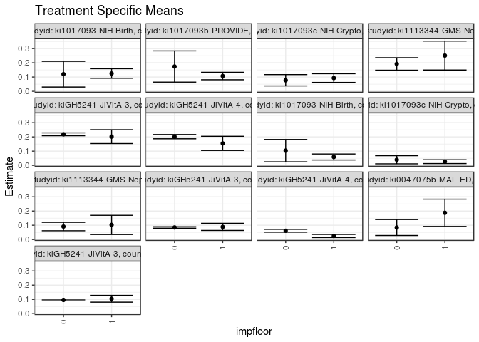

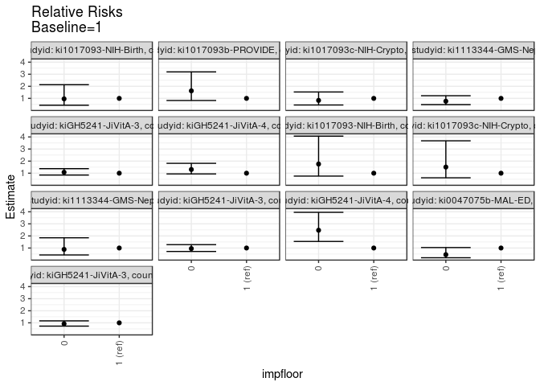

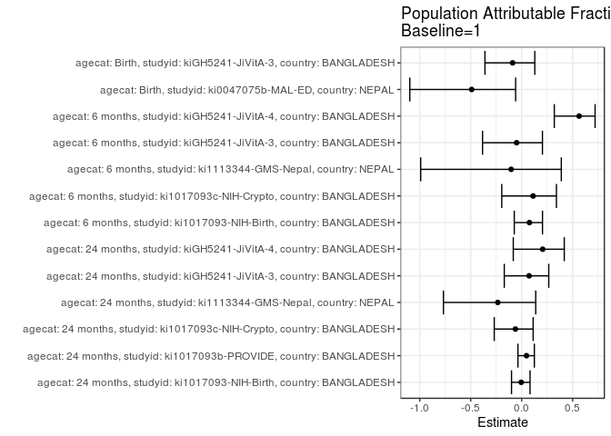

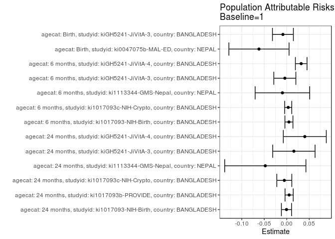

## Results Table

### Parameter: TSM

| agecat | studyid | country | intervention_level | baseline_level | estimate | ci_lower | ci_upper |
| --- | --- | --- | --- | --- | --- | --- | --- |
| Birth | ki0047075b-MAL-ED | NEPAL | 1 | NA | 0.1875000 | 0.0915731 | 0.2834269 |
| Birth | ki0047075b-MAL-ED | NEPAL | 0 | NA | 0.0842105 | 0.0281913 | 0.1402298 |
| Birth | kiGH5241-JiVitA-3 | BANGLADESH | 1 | NA | 0.1043841 | 0.0804533 | 0.1283150 |
| Birth | kiGH5241-JiVitA-3 | BANGLADESH | 0 | NA | 0.0960991 | 0.0907454 | 0.1014527 |
| 6 months | ki1017093-NIH-Birth | BANGLADESH | 1 | NA | 0.0588235 | 0.0376661 | 0.0799809 |
| 6 months | ki1017093-NIH-Birth | BANGLADESH | 0 | NA | 0.1034483 | 0.0249987 | 0.1818978 |
| 6 months | ki1017093c-NIH-Crypto | BANGLADESH | 1 | NA | 0.0260708 | 0.0125841 | 0.0395575 |
| 6 months | ki1017093c-NIH-Crypto | BANGLADESH | 0 | NA | 0.0393258 | 0.0107520 | 0.0678997 |
| 6 months | ki1113344-GMS-Nepal | NEPAL | 1 | NA | 0.1025641 | 0.0351589 | 0.1699693 |
| 6 months | ki1113344-GMS-Nepal | NEPAL | 0 | NA | 0.0909091 | 0.0613020 | 0.1205161 |
| 6 months | kiGH5241-JiVitA-3 | BANGLADESH | 1 | NA | 0.0885797 | 0.0635183 | 0.1136410 |
| 6 months | kiGH5241-JiVitA-3 | BANGLADESH | 0 | NA | 0.0846371 | 0.0795988 | 0.0896754 |
| 6 months | kiGH5241-JiVitA-4 | BANGLADESH | 1 | NA | 0.0248595 | 0.0138798 | 0.0358393 |
| 6 months | kiGH5241-JiVitA-4 | BANGLADESH | 0 | NA | 0.0614554 | 0.0515260 | 0.0713847 |
| 24 months | ki1017093-NIH-Birth | BANGLADESH | 1 | NA | 0.1250000 | 0.0915325 | 0.1584675 |
| 24 months | ki1017093-NIH-Birth | BANGLADESH | 0 | NA | 0.1200000 | 0.0298210 | 0.2101790 |
| 24 months | ki1017093b-PROVIDE | BANGLADESH | 1 | NA | 0.1071429 | 0.0808377 | 0.1334480 |
| 24 months | ki1017093b-PROVIDE | BANGLADESH | 0 | NA | 0.1739130 | 0.0642844 | 0.2835417 |
| 24 months | ki1017093c-NIH-Crypto | BANGLADESH | 1 | NA | 0.0929148 | 0.0623953 | 0.1234343 |
| 24 months | ki1017093c-NIH-Crypto | BANGLADESH | 0 | NA | 0.0773101 | 0.0376071 | 0.1170131 |
| 24 months | ki1113344-GMS-Nepal | NEPAL | 1 | NA | 0.2507591 | 0.1492148 | 0.3523034 |
| 24 months | ki1113344-GMS-Nepal | NEPAL | 0 | NA | 0.1918861 | 0.1480546 | 0.2357177 |
| 24 months | kiGH5241-JiVitA-3 | BANGLADESH | 1 | NA | 0.2020910 | 0.1533244 | 0.2508575 |
| 24 months | kiGH5241-JiVitA-3 | BANGLADESH | 0 | NA | 0.2181819 | 0.2080631 | 0.2283007 |
| 24 months | kiGH5241-JiVitA-4 | BANGLADESH | 1 | NA | 0.1544466 | 0.1045937 | 0.2042995 |
| 24 months | kiGH5241-JiVitA-4 | BANGLADESH | 0 | NA | 0.2017302 | 0.1868517 | 0.2166088 |

### Parameter: E(Y)

| agecat | studyid | country | intervention_level | baseline_level | estimate | ci_lower | ci_upper |
| --- | --- | --- | --- | --- | --- | --- | --- |
| Birth | ki0047075b-MAL-ED | NEPAL | NA | NA | 0.1257862 | 0.0740797 | 0.1774926 |
| Birth | kiGH5241-JiVitA-3 | BANGLADESH | NA | NA | 0.0958764 | 0.0906733 | 0.1010796 |
| 6 months | ki1017093-NIH-Birth | BANGLADESH | NA | NA | 0.0636704 | 0.0429419 | 0.0843989 |
| 6 months | ki1017093c-NIH-Crypto | BANGLADESH | NA | NA | 0.0293706 | 0.0169860 | 0.0417552 |
| 6 months | ki1113344-GMS-Nepal | NEPAL | NA | NA | 0.0929705 | 0.0658371 | 0.1201040 |
| 6 months | kiGH5241-JiVitA-3 | BANGLADESH | NA | NA | 0.0843784 | 0.0795716 | 0.0891851 |
| 6 months | kiGH5241-JiVitA-4 | BANGLADESH | NA | NA | 0.0569830 | 0.0481380 | 0.0658280 |
| 24 months | ki1017093-NIH-Birth | BANGLADESH | NA | NA | 0.1244131 | 0.0930343 | 0.1557919 |
| 24 months | ki1017093b-PROVIDE | BANGLADESH | NA | NA | 0.1124567 | 0.0866788 | 0.1382347 |
| 24 months | ki1017093c-NIH-Crypto | BANGLADESH | NA | NA | 0.0875486 | 0.0630907 | 0.1120065 |
| 24 months | ki1113344-GMS-Nepal | NEPAL | NA | NA | 0.2031250 | 0.1628324 | 0.2434176 |
| 24 months | kiGH5241-JiVitA-3 | BANGLADESH | NA | NA | 0.2179487 | 0.2080959 | 0.2278016 |
| 24 months | kiGH5241-JiVitA-4 | BANGLADESH | NA | NA | 0.1945443 | 0.1813282 | 0.2077604 |

### Parameter: RR

| agecat | studyid | country | intervention_level | baseline_level | estimate | ci_lower | ci_upper |
| --- | --- | --- | --- | --- | --- | --- | --- |
| Birth | ki0047075b-MAL-ED | NEPAL | 1 | 1 | 1.0000000 | 1.0000000 | 1.000000 |
| Birth | ki0047075b-MAL-ED | NEPAL | 0 | 1 | 0.4491228 | 0.1940442 | 1.039512 |
| Birth | kiGH5241-JiVitA-3 | BANGLADESH | 1 | 1 | 1.0000000 | 1.0000000 | 1.000000 |
| Birth | kiGH5241-JiVitA-3 | BANGLADESH | 0 | 1 | 0.9206293 | 0.7288707 | 1.162838 |
| 6 months | ki1017093-NIH-Birth | BANGLADESH | 1 | 1 | 1.0000000 | 1.0000000 | 1.000000 |
| 6 months | ki1017093-NIH-Birth | BANGLADESH | 0 | 1 | 1.7586207 | 0.7597329 | 4.070834 |
| 6 months | ki1017093c-NIH-Crypto | BANGLADESH | 1 | 1 | 1.0000000 | 1.0000000 | 1.000000 |
| 6 months | ki1017093c-NIH-Crypto | BANGLADESH | 0 | 1 | 1.5084270 | 0.6182469 | 3.680329 |
| 6 months | ki1113344-GMS-Nepal | NEPAL | 1 | 1 | 1.0000000 | 1.0000000 | 1.000000 |
| 6 months | ki1113344-GMS-Nepal | NEPAL | 0 | 1 | 0.8863636 | 0.4256670 | 1.845669 |
| 6 months | kiGH5241-JiVitA-3 | BANGLADESH | 1 | 1 | 1.0000000 | 1.0000000 | 1.000000 |
| 6 months | kiGH5241-JiVitA-3 | BANGLADESH | 0 | 1 | 0.9554910 | 0.7145768 | 1.277628 |
| 6 months | kiGH5241-JiVitA-4 | BANGLADESH | 1 | 1 | 1.0000000 | 1.0000000 | 1.000000 |
| 6 months | kiGH5241-JiVitA-4 | BANGLADESH | 0 | 1 | 2.4721034 | 1.5455580 | 3.954103 |
| 24 months | ki1017093-NIH-Birth | BANGLADESH | 1 | 1 | 1.0000000 | 1.0000000 | 1.000000 |
| 24 months | ki1017093-NIH-Birth | BANGLADESH | 0 | 1 | 0.9600000 | 0.4323222 | 2.131743 |
| 24 months | ki1017093b-PROVIDE | BANGLADESH | 1 | 1 | 1.0000000 | 1.0000000 | 1.000000 |
| 24 months | ki1017093b-PROVIDE | BANGLADESH | 0 | 1 | 1.6231884 | 0.8252271 | 3.192746 |
| 24 months | ki1017093c-NIH-Crypto | BANGLADESH | 1 | 1 | 1.0000000 | 1.0000000 | 1.000000 |
| 24 months | ki1017093c-NIH-Crypto | BANGLADESH | 0 | 1 | 0.8320535 | 0.4518965 | 1.532017 |
| 24 months | ki1113344-GMS-Nepal | NEPAL | 1 | 1 | 1.0000000 | 1.0000000 | 1.000000 |
| 24 months | ki1113344-GMS-Nepal | NEPAL | 0 | 1 | 0.7652210 | 0.4803614 | 1.219006 |
| 24 months | kiGH5241-JiVitA-3 | BANGLADESH | 1 | 1 | 1.0000000 | 1.0000000 | 1.000000 |
| 24 months | kiGH5241-JiVitA-3 | BANGLADESH | 0 | 1 | 1.0796223 | 0.8470561 | 1.376041 |
| 24 months | kiGH5241-JiVitA-4 | BANGLADESH | 1 | 1 | 1.0000000 | 1.0000000 | 1.000000 |
| 24 months | kiGH5241-JiVitA-4 | BANGLADESH | 0 | 1 | 1.3061487 | 0.9389584 | 1.816933 |

### Parameter: PAR

| agecat | studyid | country | intervention_level | baseline_level | estimate | ci_lower | ci_upper |
| --- | --- | --- | --- | --- | --- | --- | --- |
| Birth | ki0047075b-MAL-ED | NEPAL | 1 | NA | -0.0617138 | -0.1285543 | 0.0051267 |
| Birth | kiGH5241-JiVitA-3 | BANGLADESH | 1 | NA | -0.0085077 | -0.0317599 | 0.0147445 |
| 6 months | ki1017093-NIH-Birth | BANGLADESH | 1 | NA | 0.0048469 | -0.0040567 | 0.0137504 |
| 6 months | ki1017093c-NIH-Crypto | BANGLADESH | 1 | NA | 0.0032999 | -0.0045774 | 0.0111771 |
| 6 months | ki1113344-GMS-Nepal | NEPAL | 1 | NA | -0.0095936 | -0.0701945 | 0.0510073 |
| 6 months | kiGH5241-JiVitA-3 | BANGLADESH | 1 | NA | -0.0042013 | -0.0286873 | 0.0202847 |
| 6 months | kiGH5241-JiVitA-4 | BANGLADESH | 1 | NA | 0.0321235 | 0.0191872 | 0.0450598 |
| 24 months | ki1017093-NIH-Birth | BANGLADESH | 1 | NA | -0.0005869 | -0.0118777 | 0.0107040 |
| 24 months | ki1017093b-PROVIDE | BANGLADESH | 1 | NA | 0.0053139 | -0.0037789 | 0.0144067 |
| 24 months | ki1017093c-NIH-Crypto | BANGLADESH | 1 | NA | -0.0053661 | -0.0220205 | 0.0112882 |
| 24 months | ki1113344-GMS-Nepal | NEPAL | 1 | NA | -0.0476341 | -0.1378529 | 0.0425847 |
| 24 months | kiGH5241-JiVitA-3 | BANGLADESH | 1 | NA | 0.0158577 | -0.0312023 | 0.0629178 |
| 24 months | kiGH5241-JiVitA-4 | BANGLADESH | 1 | NA | 0.0400977 | -0.0076411 | 0.0878365 |

### Parameter: PAF

| agecat | studyid | country | intervention_level | baseline_level | estimate | ci_lower | ci_upper |
| --- | --- | --- | --- | --- | --- | --- | --- |
| Birth | ki0047075b-MAL-ED | NEPAL | 1 | NA | -0.4906250 | -1.0974070 | -0.0593857 |
| Birth | kiGH5241-JiVitA-3 | BANGLADESH | 1 | NA | -0.0887360 | -0.3603292 | 0.1286330 |
| 6 months | ki1017093-NIH-Birth | BANGLADESH | 1 | NA | 0.0761246 | -0.0726042 | 0.2042304 |
| 6 months | ki1017093c-NIH-Crypto | BANGLADESH | 1 | NA | 0.1123526 | -0.1953934 | 0.3408714 |
| 6 months | ki1113344-GMS-Nepal | NEPAL | 1 | NA | -0.1031895 | -0.9908790 | 0.3886986 |
| 6 months | kiGH5241-JiVitA-3 | BANGLADESH | 1 | NA | -0.0497911 | -0.3839907 | 0.2037075 |
| 6 months | kiGH5241-JiVitA-4 | BANGLADESH | 1 | NA | 0.5637375 | 0.3200220 | 0.7201013 |
| 24 months | ki1017093-NIH-Birth | BANGLADESH | 1 | NA | -0.0047170 | -0.0996885 | 0.0820526 |
| 24 months | ki1017093b-PROVIDE | BANGLADESH | 1 | NA | 0.0472527 | -0.0365321 | 0.1242651 |
| 24 months | ki1017093c-NIH-Crypto | BANGLADESH | 1 | NA | -0.0612933 | -0.2691545 | 0.1125246 |
| 24 months | ki1113344-GMS-Nepal | NEPAL | 1 | NA | -0.2345063 | -0.7675321 | 0.1377775 |
| 24 months | kiGH5241-JiVitA-3 | BANGLADESH | 1 | NA | 0.0727591 | -0.1707037 | 0.2655907 |
| 24 months | kiGH5241-JiVitA-4 | BANGLADESH | 1 | NA | 0.2061108 | -0.0824516 | 0.4177476 |